# Homework-7

Kylie Knudten

2023-03-25

# Homework 7

Link to my github repo:

https://github.com/kknudten/Homework-7.git

```r
# access data for assignment:
HAPPY <- readRDS("data/HAPPY.rds")
head(HAPPY)
```

```
##           HAPPY YEAR AGE    SEX       MARITAL         DEGREE       FINRELA
## 1 NOT TOO HAPPY 1972  23 FEMALE NEVER MARRIED       BACHELOR       AVERAGE
## 2 NOT TOO HAPPY 1972  70   MALE       MARRIED LT HIGH SCHOOL ABOVE AVERAGE
## 3  PRETTY HAPPY 1972  48 FEMALE       MARRIED    HIGH SCHOOL       AVERAGE
## 4 NOT TOO HAPPY 1972  27 FEMALE       MARRIED       BACHELOR       AVERAGE
## 5  PRETTY HAPPY 1972  61 FEMALE       MARRIED    HIGH SCHOOL ABOVE AVERAGE
## 6  PRETTY HAPPY 1972  26   MALE NEVER MARRIED    HIGH SCHOOL ABOVE AVERAGE
##      HEALTH WTSSALL          PARTYID POLVIEWS
## 1      GOOD  0.4446     IND,NEAR DEM      IAP
## 2      FAIR  0.8893 NOT STR DEMOCRAT      IAP
## 3 EXCELLENT  0.8893      INDEPENDENT      IAP
## 4      GOOD  0.8893 NOT STR DEMOCRAT      IAP
## 5      GOOD  0.8893  STRONG DEMOCRAT      IAP
## 6      GOOD  0.4446     IND,NEAR DEM      IAP
```

## Part One (Cleaning)

1. Data cleaning: the values “IAP”, “DK”, and “NA” all encode missing values. Replace all of these instances by the value NA.

   ```r
   HAPPY[HAPPY == "IAP"] <- NA
   HAPPY[HAPPY == "DK"] <- NA
   HAPPY[HAPPY == "NA"] <- NA
   head(HAPPY)
   ```

   ```
   ##           HAPPY YEAR AGE    SEX       MARITAL         DEGREE       FINRELA
   ## 1 NOT TOO HAPPY 1972  23 FEMALE NEVER MARRIED       BACHELOR       AVERAGE
   ## 2 NOT TOO HAPPY 1972  70   MALE       MARRIED LT HIGH SCHOOL ABOVE AVERAGE
   ## 3  PRETTY HAPPY 1972  48 FEMALE       MARRIED    HIGH SCHOOL       AVERAGE
   ## 4 NOT TOO HAPPY 1972  27 FEMALE       MARRIED       BACHELOR       AVERAGE
   ## 5  PRETTY HAPPY 1972  61 FEMALE       MARRIED    HIGH SCHOOL ABOVE AVERAGE
   ## 6  PRETTY HAPPY 1972  26   MALE NEVER MARRIED    HIGH SCHOOL ABOVE AVERAGE
   ##      HEALTH WTSSALL          PARTYID POLVIEWS
   ## 1      GOOD  0.4446     IND,NEAR DEM     <NA>
   ## 2      FAIR  0.8893 NOT STR DEMOCRAT     <NA>
   ## 3 EXCELLENT  0.8893      INDEPENDENT     <NA>
   ## 4      GOOD  0.8893 NOT STR DEMOCRAT     <NA>
   ## 5      GOOD  0.8893  STRONG DEMOCRAT     <NA>
   ## 6      GOOD  0.4446     IND,NEAR DEM     <NA>
   ```

2. Check the type of the variable and cast into the right type (factor variable for categorical variables). For age, change “89 OR OLDER” to 89 and assume the variable should be numeric.

   ```r
   # check/display type for each variable
   str(HAPPY)
   ```

   ```
   ## 'data.frame':    62466 obs. of  11 variables:
   ##  $ HAPPY   : chr  "NOT TOO HAPPY" "NOT TOO HAPPY" "PRETTY HAPPY" "NOT TOO HAPPY" ...
   ##  $ YEAR    : int  1972 1972 1972 1972 1972 1972 1972 1972 1972 1972 ...
   ##  $ AGE     : chr  "23" "70" "48" "27" ...
   ##  $ SEX     : chr  "FEMALE" "MALE" "FEMALE" "FEMALE" ...
   ##  $ MARITAL : chr  "NEVER MARRIED" "MARRIED" "MARRIED" "MARRIED" ...
   ##  $ DEGREE  : chr  "BACHELOR" "LT HIGH SCHOOL" "HIGH SCHOOL" "BACHELOR" ...
   ##  $ FINRELA : chr  "AVERAGE" "ABOVE AVERAGE" "AVERAGE" "AVERAGE" ...
   ##  $ HEALTH  : chr  "GOOD" "FAIR" "EXCELLENT" "GOOD" ...
   ##  $ WTSSALL : num  0.445 0.889 0.889 0.889 0.889 ...
   ##  $ PARTYID : chr  "IND,NEAR DEM" "NOT STR DEMOCRAT" "INDEPENDENT" "NOT STR DEMOCRAT" ...
   ##  $ POLVIEWS: chr  NA NA NA NA ...
   ```

   ```r
   # cast categorical variables as factors
   HAPPY$HAPPY = as.factor(HAPPY$HAPPY)
   HAPPY$SEX = as.factor(HAPPY$SEX)
   HAPPY$MARITAL = as.factor(HAPPY$MARITAL)
   HAPPY$DEGREE = as.factor(HAPPY$DEGREE)
   HAPPY$FINRELA = as.factor(HAPPY$FINRELA)
   HAPPY$HEALTH = as.factor(HAPPY$HEALTH)
   HAPPY$PARTYID = as.factor(HAPPY$PARTYID)
   HAPPY$POLVIEWS = as.factor(HAPPY$POLVIEWS)

   # edit age "89 OR OLDER" to 89 and cast to numeric
   HAPPY[HAPPY == "89 OR OLDER"] <- 89
   HAPPY$AGE = as.numeric(HAPPY$AGE)
   ```

3. Bring all levels of factors into a sensible order. For marital you could e.g. order the levels according to average age.

   Save the final data set as RDS file (binary R data) using the command: saveRDS.

   ```r
   HAPPY$HAPPY = factor(HAPPY$HAPPY, levels = c("NOT TOO HAPPY", "PRETTY HAPPY", "VERY HAPPY"))

   HAPPY$SEX = factor(HAPPY$SEX, levels = c("MALE", "FEMALE"))

   HAPPY$MARITAL = factor(HAPPY$MARITAL, levels = levels(reorder(HAPPY$MARITAL, HAPPY$AGE, mean, na.rm=TRUE)))

   HAPPY$DEGREE = factor(HAPPY$DEGREE, levels = c("LT HIGH SCHOOL", "HIGH SCHOOL", "JUNIOR COLLEGE", "BACHELOR", "GRADUATE"))

   HAPPY$FINRELA = factor(HAPPY$FINRELA, levels = c("FAR BELOW AVERAGE", "BELOW AVERAGE", "AVERAGE", "ABOVE AVERAGE", "FAR ABOVE AVERAGE"))

   HAPPY$HEALTH = factor(HAPPY$HEALTH, levels = c("POOR", "FAIR", "GOOD", "EXCELLENT"))

   HAPPY$PARTYID = factor(HAPPY$PARTYID, levels = c("STRONG DEMOCRAT", "NOT STR DEMOCRAT", "STRONG REPUBLICAN", "NOT STR REPUBLICAN", "IND,NEAR DEM", "INDEPENDENT", "IND,NEAR REP", "OTHER PARTY"))

   HAPPY$POLVIEWS = factor(HAPPY$POLVIEWS, levels = levels(reorder(HAPPY$POLVIEWS, HAPPY$AGE, mean, na.rm=TRUE)))
   str(HAPPY)
   ```

   ```
   ## 'data.frame':    62466 obs. of  11 variables:
   ##  $ HAPPY   : Factor w/ 3 levels "NOT TOO HAPPY",..: 1 1 2 1 2 2 1 1 2 2 ...
   ##  $ YEAR    : int  1972 1972 1972 1972 1972 1972 1972 1972 1972 1972 ...
   ##  $ AGE     : num  23 70 48 27 61 26 28 27 21 30 ...
   ##  $ SEX     : Factor w/ 2 levels "MALE","FEMALE": 2 1 2 2 2 1 1 1 2 2 ...
   ##  $ MARITAL : Factor w/ 5 levels "NEVER MARRIED",..: 1 3 3 3 3 1 4 1 1 3 ...
   ##  $ DEGREE  : Factor w/ 5 levels "LT HIGH SCHOOL",..: 4 1 2 4 2 2 2 4 2 2 ...
   ##  $ FINRELA : Factor w/ 5 levels "FAR BELOW AVERAGE",..: 3 4 3 3 4 4 4 3 3 2 ...
   ##  $ HEALTH  : Factor w/ 4 levels "POOR","FAIR",..: 3 2 4 3 3 3 4 3 4 2 ...
   ##  $ WTSSALL : num  0.445 0.889 0.889 0.889 0.889 ...
   ##  $ PARTYID : Factor w/ 8 levels "STRONG DEMOCRAT",..: 5 2 6 2 1 5 5 5 1 1 ...
   ##  $ POLVIEWS: Factor w/ 7 levels "SLIGHTLY LIBERAL",..: NA NA NA NA NA NA NA NA NA NA ...
   ```

   ```r
   saveRDS(HAPPY, file="HAPPY1")
   ```

## Part Two (individual exploration)

Investigate the relationship between happiness and two other variables in the data. Find a visualization that captures the relationship and write a paragraph to describe it.

Question 1: Which gender is happier?

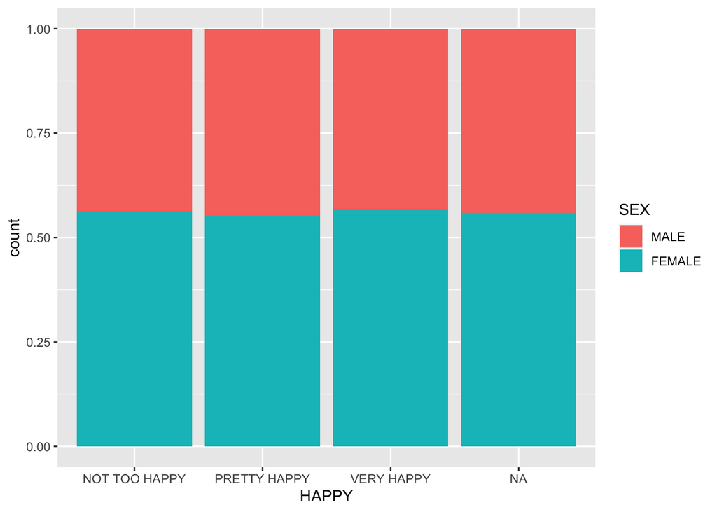

```r
library(ggplot2)
ggplot(HAPPY, aes(x = HAPPY, fill = SEX)) + geom_bar(position="fill")
```

For this first visual, it appears that women have the majority in every happiness level over men. This could be due to there being more women participants in this data set. It is hard to tell much of a difference in proportions between happiness levels, but it appears that the level where the men’s proportion is the largest is for category “PRETTY HAPPY”. In order to possibly look at happiness and account for uneven group numbers between sexes, I have switched the mosaic axes as shown in the next visual.

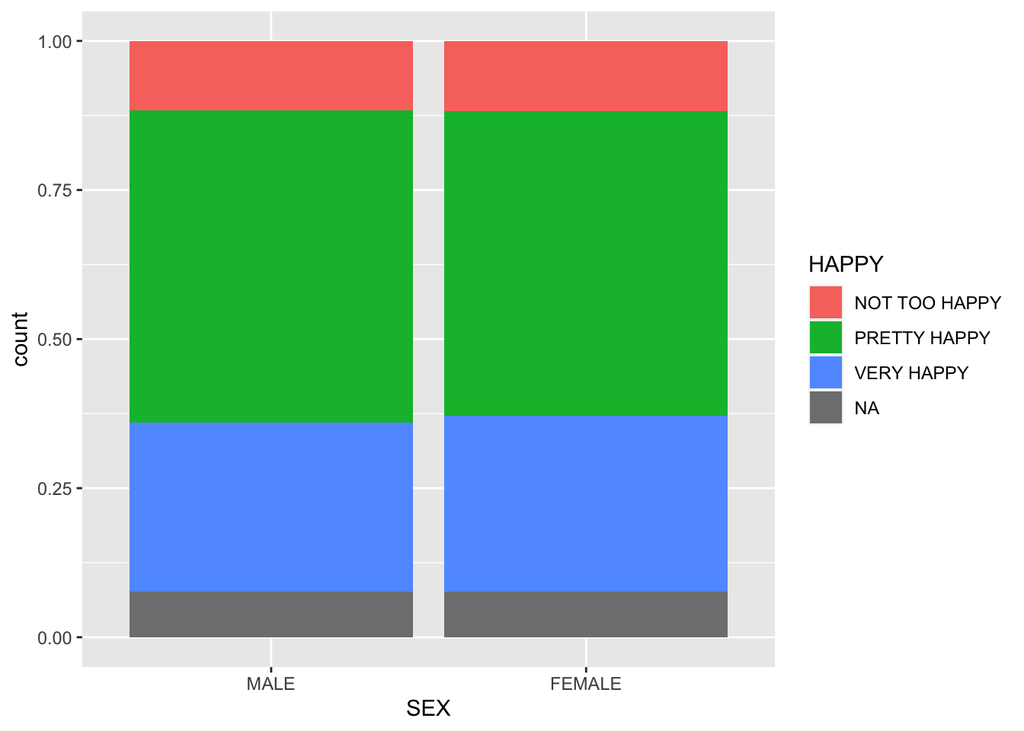

```r
ggplot(HAPPY, aes(x=SEX, fill=HAPPY)) + geom_bar(position="fill")
```

In this format, we can see that males and females actually are very similarly distributed among the happiness spectrum. It appears that for both genders, a small proportion are not too happy, the largest proportion are pretty happy, and the second largest proportion are very happy. For both genders, less than 25% are not too happy.

Question 2: Does health influence happiness?

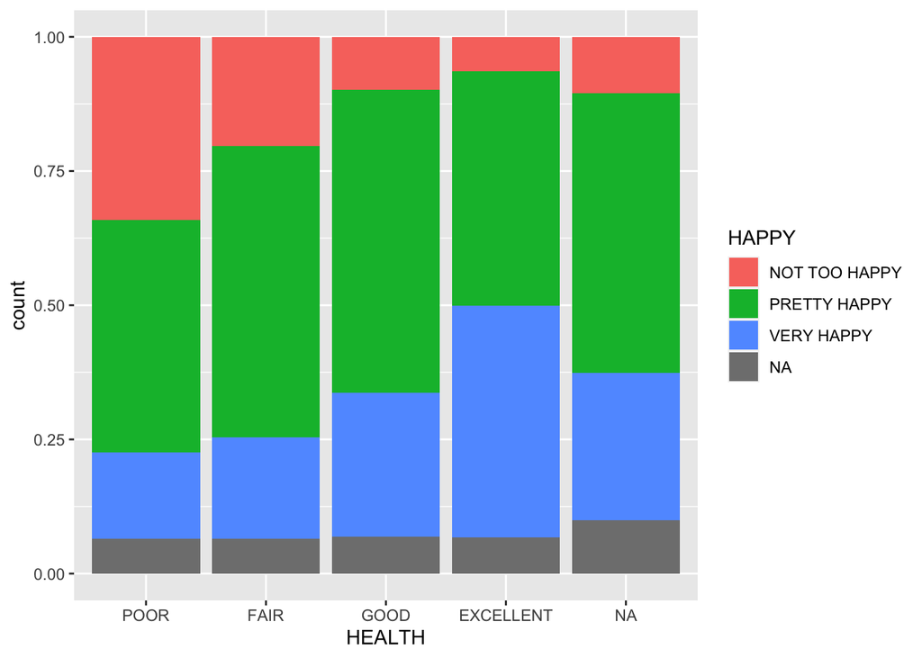

```r
ggplot(HAPPY, aes(x=HEALTH, fill=HAPPY)) + geom_bar(position="fill")
```

This visual definitely gives more valuable information than the gender one. It appears that the happiness level “NOT TOO HAPPY” is its highest for people with poor health. The happiness level “NOT TOO HAPPY” is the lowest for people in excellent health. In addition, the happiness level “VERY HAPPY” is at its highest for people with excellent health. The overall graph trend is that as people’s health level improves, they become more happy.

Upload your answers and the dataset to the repository.